# Happy Moments

Izzy Beers, ib2392

9/20/2018

Most days, people experience many different events, both social and individual. People may go to work or go out with their friends, but they probably also have some alone time at certain points throughout the day, whether they’re reading the newspaper, watching TV, or going to the grocery store. If Amazon asked you to report a happy moment that happened to you in the past 24 hours, there are probably many different moments that you can choose from, both social and individual. However, you can’t report every single moment that happened throughout the day, so you have to choose the moment that was the most enjoyable or the most memorable. What types of moments do people typically choose? Is there a relationship between a person’s demographic and the types of moments they choose to report? What are some of the most common individual and social activities that people talk about?

For my analysis of these happy moments, I was interested in categorizing these moments based on whether it was mainly a social event or an individual event. I was able to come up with a pattern for R to follow to classify a moment as an individual or social moment, while minimizing the amount of “false negatives” and “false positives”. Now that each moment is classified, these questions can be answered.

### Section 1: What Does the Data Say About Social and Individual Moments? Which Are More Common, and What Are Some of the Most Common Words and Expressions in Each?

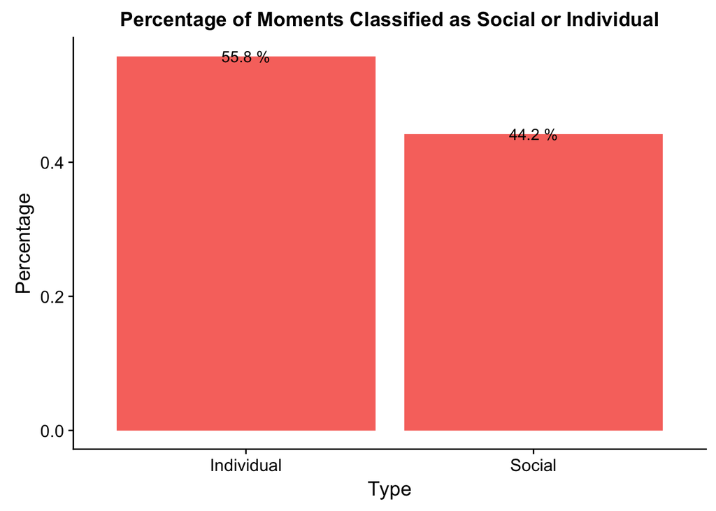

#### Most Common Words In Social Moments:

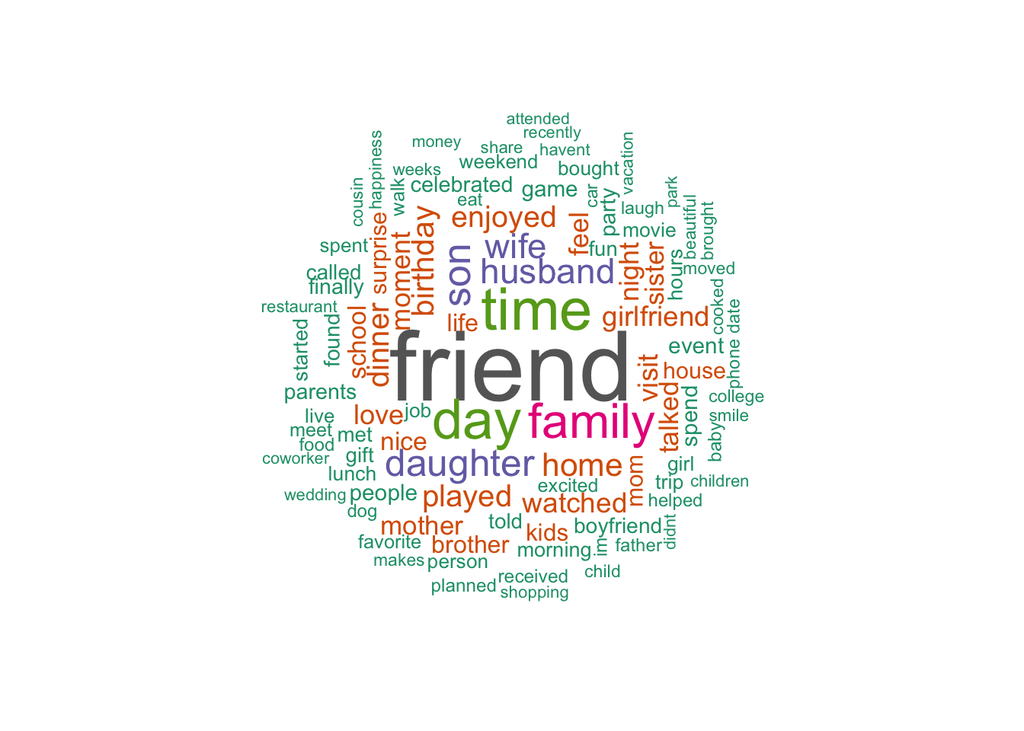

#### Most Common Words In Individual Moments:

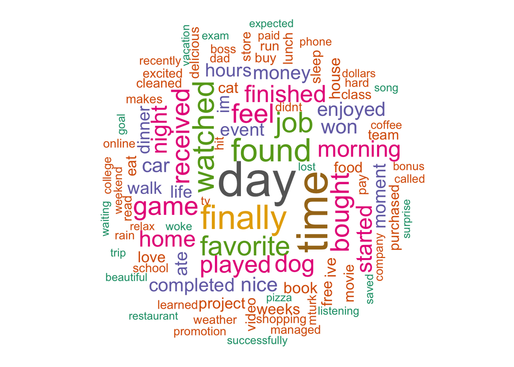

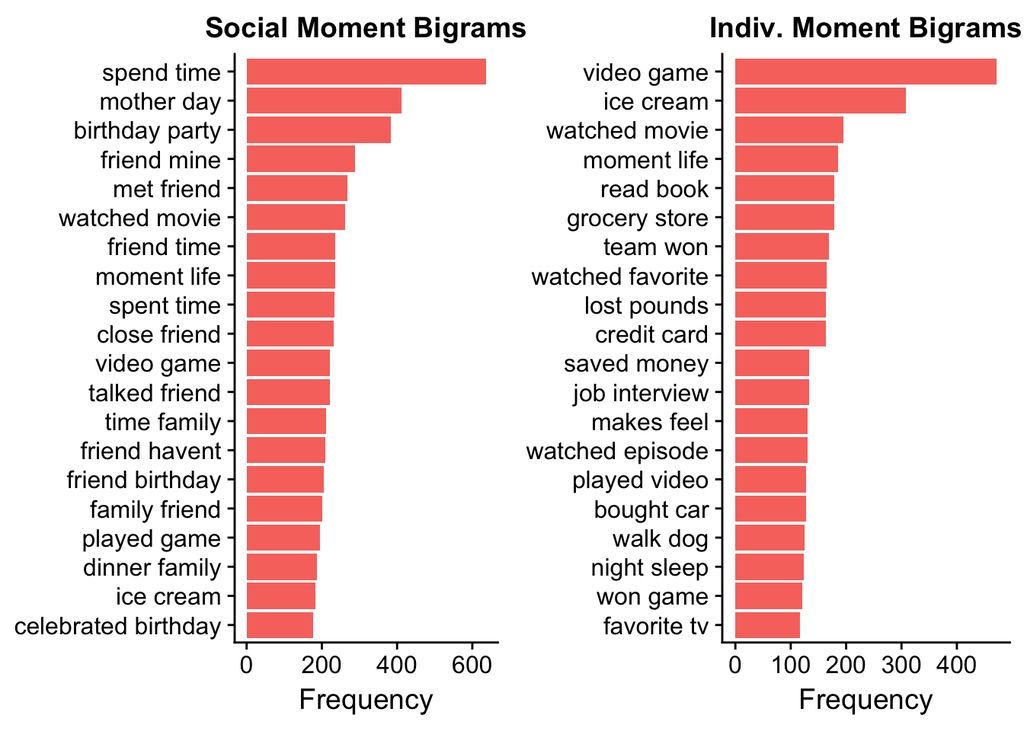

### Section 2: How Are Demographics Related To Moment Types (social vs. individual)?

Now that the data has given us an idea of the most common words used in social and individual moments by all types of people, how does a person’s gender, marital status, parenthood status, age, and home country relate to what type of moment they wrote about (social or individual)?

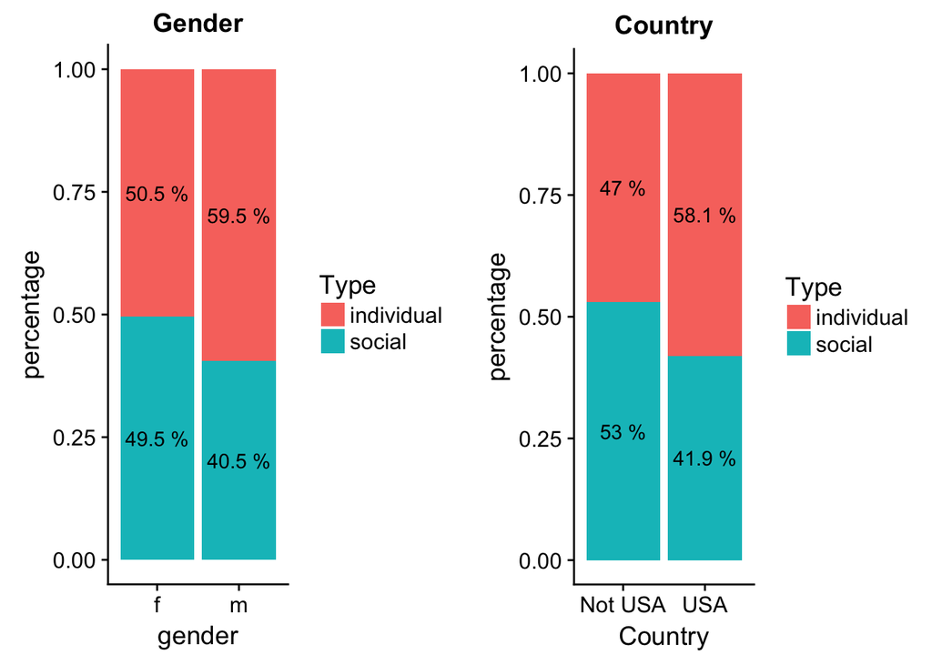

The data shows that females appear to be approximately equally likely to report a social or individual moment, but for males, there were a lot more individual moments.

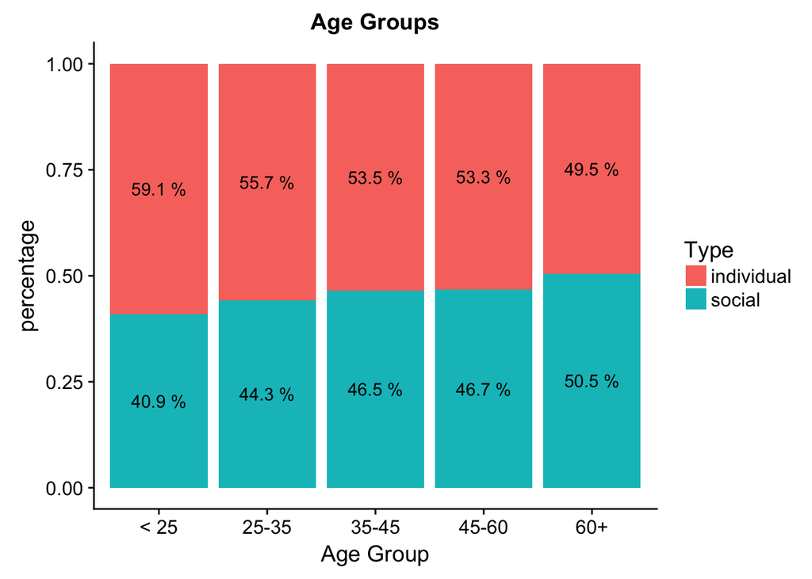

The data also shows that as people get older, they are more likely to report a social moment. The gap between individual and social gets smaller as the age groups increase. Could this likely be because of parenthood and marital status?

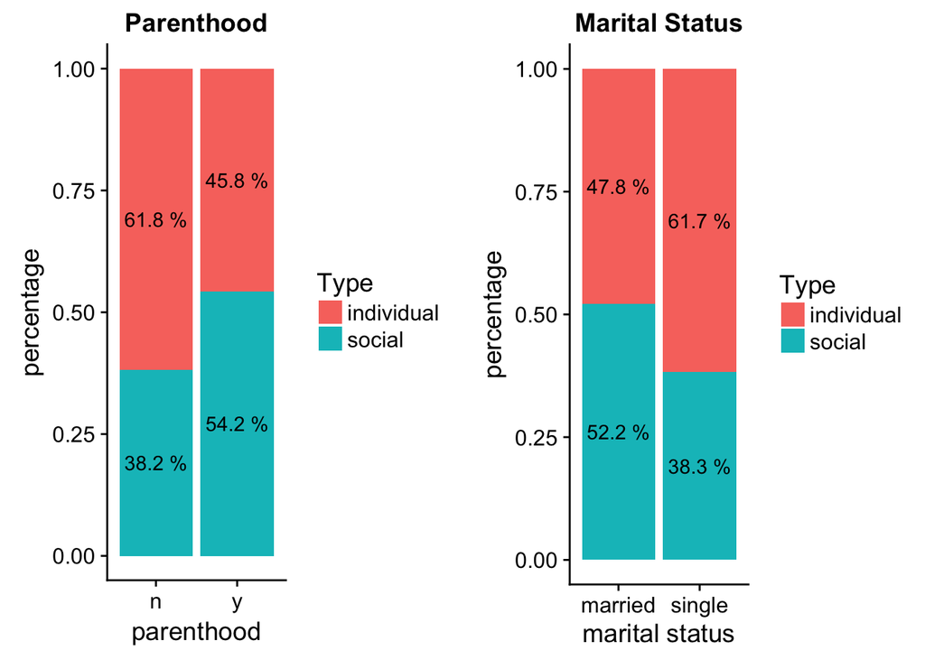

Indeed, those who are parents and those who are married both had a higher rate of social moments, and the non-parents and the singles much more often reported an individual moment. Since the results for parenthood and marital status were strikingly similar, I decided to go further and see how much overlap there is between these two groups.

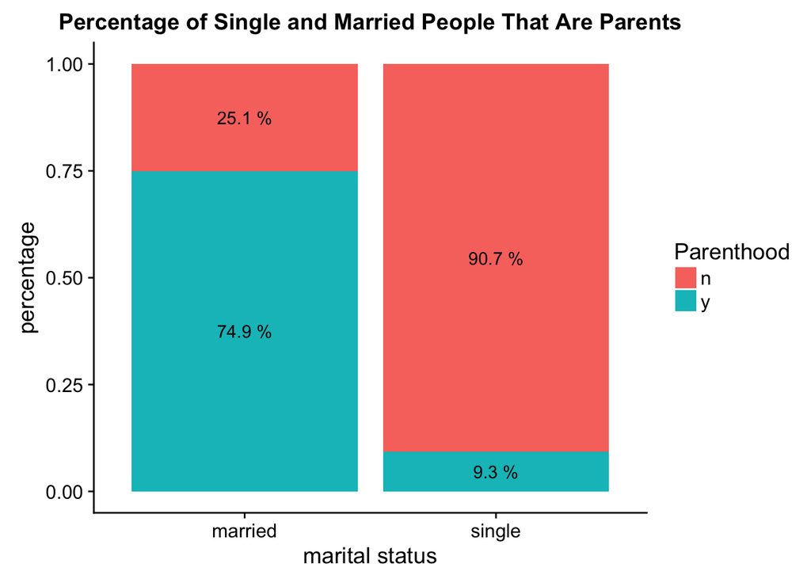

According to this plot, there is a large overlap between these two groups. Most of the married people are parents, and almost none of the single people are parents. So it makes sense that the distribution of social and individual classifications would be similar for both groups.

So in summary, the largest social groups from this analysis were older people, married people, parents, females, and non-Americans. My hypothesis going into this project was that younger people would have more social moments because it is that generation and age group that craves the excitement of a party or being surrounded by friends, and it seems like the adults are the ones that value their alone time more. However, this data shows that it is the older people, married people, and parents that are more likely to highlight their social activities, which could likely be due to the fact that these people are very family-oriented. If a mother is asked about a happy moment she had, she is likely to say something about her child.

### Section 3: What Does the Data Say About Moments With People’s Names In It?

In addition to just social vs. individual moments for each category, the data also gives some information on whether or not the moment had a name in it. What does the data say about how often a name was mentioned in a moment, and in these moments, how many did not have any reference to a social event?

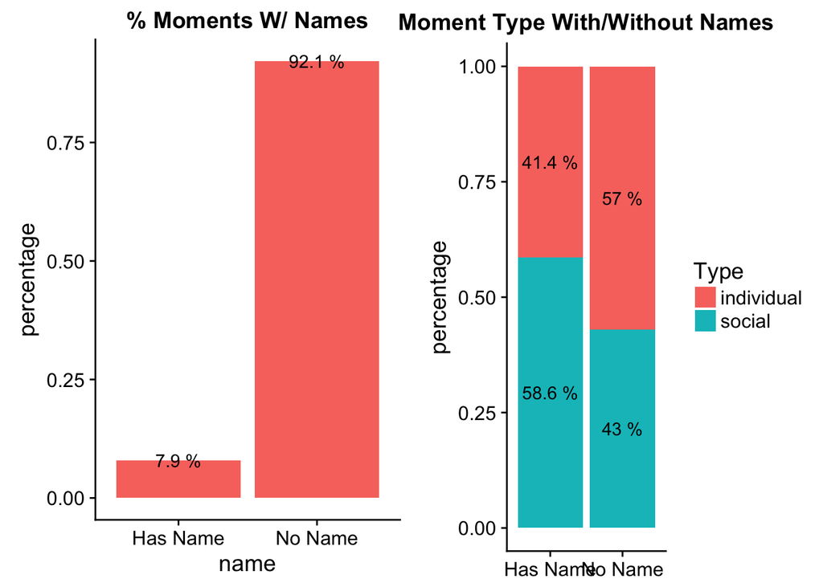

The data shows that very few people include people’s names when describing their moment. But almost half of the moments with names are not even social moments. If these people are not using a name to refer to a friend or family member, then what are they using it for?

For all individual moments that include a name, here are the most common bigrams that include names, which would show which name was used in this moment:

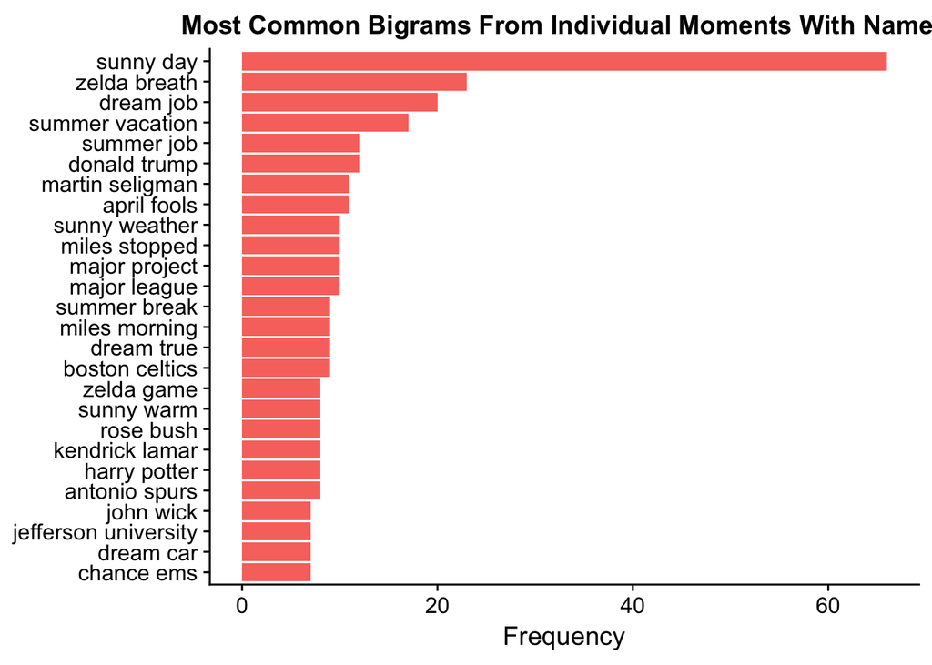